# Bedload Manual

# Background

The bedload package was created to automate the performance of various analyses that come up in applied geoscience. The philosophy of the package is to construct flexible tools that can be easily incorporated into data analysis workflows without a detailed background in R programming. It relies on other packages for importing and analyzing various types of environmental data that are used when analyzing questions related to bed material transport.

# Analysis Functions

The analysis functions in this section are designed to perform a range of commonly executed analyses. They are built with various functions from the subsequent sections. The typical workflows are presented with each analysis function.

New analysis functions will continue to be added to the `bedload` package as new use cases are developed.

## compare_fun

This function compares the transport functions for a specified grain size and channel gradient over a reasonable range of shear stress values using the default values for all functions.

### Usage

`compare_fun(d, S, d84 = 2 * d, g = 9.81, rho = 1000, rho_s = 2650)`

### Arguments

- `d` median bed sediment grain diameter (m)
- `S` gradient of the water surface slope (m/m)
- `d84` 84th percentile diameter of bed sediment (m). Defaults to `2 * d`
- `g` the acceleration of gravity. defaults to 9.81 m/s$^2$
- `rho` fluid density. Defaults to 1000 kg/m$^3$
- `rho_s` sediment density. Defaults to 2650 kg/m$^3$

### Details

This function is intended to visualize how the various transport functions compare with one another for a given grain size and energy gradient. The results depend in large part on the relative roughness of the stream be analysed, which is implicit in the choice of grain size and gradient.

### Output

The function simply produces a graph of the calculated volumetric bedload transport rate per unit width for a specified range of dimensionless shear stress values.

### Examples

Here is an example for a steep stream with high relative roughness.

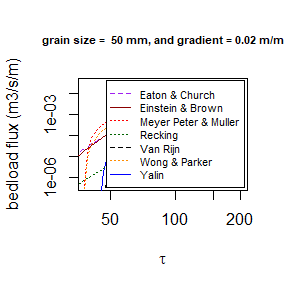

```r
compare_fun(d = 0.05,
            S = 0.02)
```

And here is an example for a stream with much lower gradient and lower relative roughness.

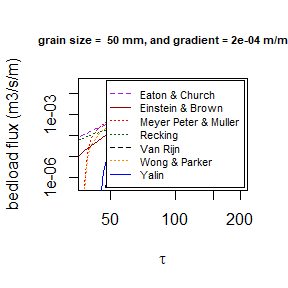

```r
compare_fun(d = 0.05,
            S = 0.0002)
```

### See also

`mpm()`, `wp()`, `eb()`, `yln()`, `vr()`, `ec()`, `rk()`

## estimate_hydraulics

this function estimates hydraulic properties at regular WSE elevation intervals, effectively building a rating curve and mapping out the at-a-station hydraulic geometry for the cross section being analyzed. These data can be used to interpolate values for target flow values. The calculations include estimates of the bedload flux calculated using one of several bedload transport equations.

### Usage

`estimate_hydraulics(xs_data, S, d, d84 = 2 * d, ymax = 1.5, ...` `dx = 0.05, t_crit = t_crit_soul(d), g = 9.81, rho = 1000, ...` `rho_s = 2650, a1 = 6.5, a2 = 2.5, kv = 1e-06, fun = "ec", rp = FALSE)`

### Details

This function uses the Ferguson (2007) flow resistance equation to calculate the velocity for a sequence of water depths at a given cross section. It builds a dataset of hydraulic geometry values (mean depth, water surface width, wetted perimeter), and cross section-average hydraulic parameters (velocity, shear stress, bedload transport capacity) for a range of discharges.

### Output

The function produces a data frame containing estimates of the mean area of flow (area),flow width (width), wetted parameter (perimeter), mean flow velocity (velocity), bed load transport capacity (transport), water surface elevation (wse), and dimensionless shear stress (t_star) for a range of discharge values (flow).

### Examples

To use `estimate_hydraulics()` it is necessary to have at a minimum a topographic cross section, an estimate of the reach-average gradient, and an estimate of the mean surface grain size.

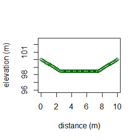

```r
example_section <- make_trapezoid(w_top = 10,
                                  w_bot = 5,
                                  H_bank = 1.5,
                                  Z_fp = 100)
plot(example_section$dist, example_section$Z,
     col = "darkgreen",
     xlab = "distance (m)",
     ylab = "elevation (m)",
     asp = 1)
```

```r
example_slope <- 0.05
example_d <- 0.04
example_result <- estimate_hydraulics(xs_data = example_section,
                                      S = example_slope,
                                      d = example_d)
head(example_result)
```

```
##         flow  area width perimeter  velocity    transport   wse     t_star
## 1 0.00000000 0.000   5.1  5.116619 0.0000000 0.0000000000 98.50 0.00000000
## 2 0.06010608 0.255   5.1  5.116619 0.2357101 0.0004518848 98.55 0.03775576
## 3 0.31137738 0.518   5.3  5.349857 0.6011146 0.0033290477 98.60 0.07335228
## 4 0.78039976 0.789   5.5  5.583095 0.9890998 0.0091788685 98.65 0.10706020
## 5 1.45819648 1.068   5.7  5.816333 1.3653525 0.0178683504 98.70 0.13910670
## 6 2.32846026 1.355   5.9  6.049571 1.7184209 0.0291474408 98.75 0.16968395
```

### See also

`load_section()`, `make_trapezoid()`,

## estimate_capacity

this function uses a data frame created by the `estimate_hydraulics()` utility function to approximate the volume of bed material that could be transported during a hydrograph. It also estimates the geomorphically active volume of transport based on a threshold dimensionless shear stress.

### Usage

`estimate_capacity(xs_hyd, Q, t, tc = 0.08, mkplt = FALSE)`

### Arguments

- `xs_hyd` a data frame created by `estimate_hydraulics()`
- `Q` a vector containing the flows that define the hydrograph
- `t` a vector that contains the corresponding times for each Q value (hours)
- `tc` the threshold dimensionless shear stress for channel change
- `mkplt` option to make a plot of the data, defaults to FALSE

### Details

This function first requires the user to create: a data frame using the `estimate_hydraulics()` function; and two vectors that define an event hydrograph over which to integrate the sediment transport capacity.

### Output

The function outputs a data frame with the following information:

- `Qmax` peak flow of the hydrograph (cubic meters per sec)
- `vol_transp` volume of bedload transported during hydrograph (cubic meters)
- `vol_active` volume of bedload transported when shear stresses exceeded a user-specified threshold dimensionless shear stress for channel change (cubic meters)
- `width` maximum width of the channel during the flood (m)
- `vel` maximum cross sectional average flow velocity (m/s)
- `area` maximum cross sectional area for flow (m$^2$/s)
- `wse` maximum water surface elevation during the peak flow (m)

### Examples

The code below provides an example of a typical work flow involved in making the calculation.

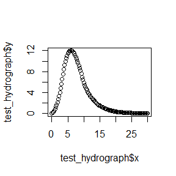

```r
# enter data that you have from the field on the site of interest
test_d <- 0.05  # median surface texture, ideally from a Wolman sample
test_d84 <- 0.12  #the 84th percentile of the bed surface
test_slope <- 0.015  # reach average bed slope from lidar or map
top_width <- 12  # bank to bank width at the site
bot_width <- 3.5  # width of the channel bed
bank_ht <- 1.2  # vertical high of the floodplain above the channel bed

# make a cross section for analysis based on field measurements
#(you can also is load_section() to load a more detailt topo profile)
test_section <- make_trapezoid(w_top = top_width,
                               w_bot = bot_width,
                               H_bank = bank_ht,
                               Z_fp = 100)

# use the scs_hydrograph() function to produce a hydrograph
test_Q_peak <- 12 # in cubic meters per second
test_time_lag <- 6 #in hours
test_dt <- 15/60 #produce discharge output every 15 minutes
test_hydrograph <- scs_hydrograph(Qpeak = test_Q_peak,
                                  tpeak = test_time_lag,
                                  dt = test_dt)
plot(test_hydrograph)
```

```r
# now we are ready to run estimate_hydraulics...
test_df <- estimate_hydraulics(xs_data = test_section,
                               S = test_slope,
                               d = test_d,
                               d84 = test_d84,
                               ymax = bank_ht * 2,
                               fun = "mpm"
                               )
# NOTE: the optional parameter ymax was assigned a value twice the channel depth...this is not strictly necessary, but ymax controls the range of water depths (and discharge values) analysed by the function, and the next step requires a data frame with discharge values at least as high as the peak flow being assessed.

# now we can run the integration over the hydrograph
test_output <- estimate_capacity(xs_hyd = test_df,
                                 Q = test_hydrograph$y,
                                 t = test_hydrograph$x)

print(test_output)
```

```
##   Qmax vol_transp vol_active    width      vel     area      wse
## 1   12   853.1535   780.8163 9.779734 2.041883 5.872919 99.68497
```

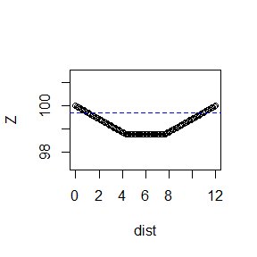

```r
# and we can show the peak water surface elevation on the cross section to check that things make sense

plot(test_section, asp = 2)
abline(h = test_output$wse, col = "blue", lty = 2)
```

### See also

`fractional_capacity()`, `bank_erode_fp`, `bank_erode_trc()`

## fractional_capacity

Integrating the Wilcock and Crowe (2003) fractional bedload transport function over a hydrograph

### Usage

`fractional_capacity( hydrograph, xs_data, S, gsd, Fsand, g = 9.81, rho = 1000, rho_s = 2650 )`

### Arguments

- `hydrograph` a data frame created by `scs_hydrograph()` (Q in m$^3$/s and t in hours
- `xs_data` a data frame containing topography expressed as dist (distances) and z (elevations)
- `S` gradient of the water surface slope (m/m)
- `gsd` a data frame describing the grain size distribution created with function `wolman_gsd()`
- `Fsand` proportion of the surface that is covered by sand sized sediment (affects entrainment, typically varies from 0 to 0.2)
- `g` the acceleration of gravity. defaults to 9.81 m/s$^2$
- `rho` fluid density. Defaults to 1000 kg/m$^3$
- `rho_s` sediment density. Defaults to 2650 kg/m$^3$

### Details

This function integrates the Wilcock and Crowe transport function over a hydrograph for a given cross section to estimate the total fractional transport volumes for the flood event. Output includes the inputted GSD information for each size class (Di, cpf, Dm, Fi), as well as the volumetric transport rate (Qbi), and the fraction of the computed bedload in each size class (Li)

### Output

The function outputs a data frame with the following information:

- `Di` grain size (in mm) of the upper size of each size class analyzed
- `cpf` cumulative proportion finer than each size `Di`
- `dm` median size for each size class analyzed
- `Fi` fraction of the bed surface in each size class
- `Qbi` volume of sediment transported during the hydrograph for each size class
- `Li` the fraction of the total transported volume in each size class

### Examples

The function is used in the following example to analyze the potential rate and grain size distribution of bedload transport in a small gravel bed stream during a flood, using the test data created to demonstrate the `estimate_capacity` function. The `wolman_gsd()` function is used to generate a data frame with the necessary grain size distribution information in it to run the Wilcock and Crowe model. Alternatively, you can use the `sim_gsd()` function to simulate a log-normal grain size distribution.

```r
#example gsd data
field_sizes <- c(16, 23, 32, 45, 64, 91, 128, 181, 256, 360)
field_counts <-c(0, 4, 7, 15, 18, 20, 17, 11, 9, 5)

test_gsd <- wolman_gsd(Di = field_sizes,
                  counts = field_counts)

#assume a percent sand for the bed surface
test_fsand <- 8 / 100

test_output <- fractional_capacity(hydrograph = test_hydrograph,
                                    xs_data = test_section,
                                    S = test_slope,
                                    gsd = test_gsd,
                                    Fsand = test_fsand)

print(test_output)
```

```
##     Di        cpf        dm         Fi          Qbi           Li
## 10 360 1.00000000 303.57866 0.04716981 5.686614e-06 1.290465e-08
## 9  256 0.95283019 215.25798 0.08490566 1.330440e-03 3.019171e-06
## 8  181 0.86792453 152.21038 0.10377358 1.555404e-01 3.529683e-04
## 7  128 0.76415094 107.92590 0.16037736 6.650807e+00 1.509269e-02
## 6   91 0.60377358  76.31514 0.18867925 3.801620e+01 8.627024e-02
## 5   64 0.41509434  53.66563 0.16981132 8.688477e+01 1.971678e-01
## 4   45 0.24528302  37.94733 0.14150943 1.341123e+02 3.043413e-01
## 3   32 0.10377358  27.12932 0.06603774 9.682496e+01 2.197251e-01
## 2   23 0.03773585  19.18333 0.03773585 7.801819e+01 1.770469e-01
## 1   16 0.00000000  16.00000 0.00000000 0.000000e+00 0.000000e+00
```

The total volume of sediment transported during the flood can be estimated by summing the values

```r
total_transport_volume <- sum(test_output$Qbi)
print(round(total_transport_volume))
```

```
## [1] 441
```

The grain size distribution of the bed material and of the load can also be compared.

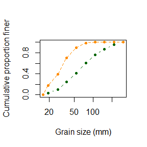

```r
plot(test_output$dm, rev(cumsum(rev(test_output$Fi))),
     type = "b",
     lty = 2,
     pch = 20,
     log = "x",
     col = "darkgreen",
     ylim = c(0, 1),
     xlab = "Grain size (mm)",
     ylab = "Cumulative proportion finer")
points(test_output$dm, rev(cumsum(rev(test_output$Li))),
       pch = 20,
      col = "darkorange")
lines(test_output$dm, rev(cumsum(rev(test_output$Li))),
      lty = 2,
      col = "darkorange")
```

This analysis can also be performed if you only have an estimate of the bed D50 and D84 by simulating a log-normal grain size distribution.

```r
#pick a D50 and log-normal standard deviation that gives the same D50 and D84 as the Wolman sample above
D50 <- approx(x = test_output$cpf,
              y = test_output$Di,
              xout = 0.5)[[2]]
sp <- 1.08

test_gsd <- sim_gsd(D50, sp)

test_output <- fractional_capacity(hydrograph = test_hydrograph,
                                    xs_data = test_section,
                                    S = test_slope,
                                    gsd = test_gsd,
                                    Fsand = test_fsand)
total_transport_volume <- sum(test_output$Qbi)
print(round(total_transport_volume))
```

```
## [1] 436
```

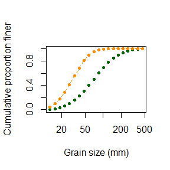

```r
plot(test_output$dm, rev(cumsum(rev(test_output$Fi))),
     type = "b",
     lty = 2,
     pch = 20,
     log = "x",
     col = "darkgreen",
     ylim = c(0, 1),
     xlab = "Grain size (mm)",
     ylab = "Cumulative proportion finer")
points(test_output$dm, rev(cumsum(rev(test_output$Li))),
       pch = 20,
      col = "darkorange")
lines(test_output$dm, rev(cumsum(rev(test_output$Li))),
      lty = 2,
      col = "darkorange")
```

In this case the field-measured and the simulated grain size distributions are quite similar, but larger differences can be expected when the actual grain size distribution is not log-normally distributed.

### See also

`estimate_capacity()`, `bank_erode_fp`, `bank_erode_trc()`

## gbem

the GBEM function: gravel-bed river bank erosion model. This function estimates the change in channel width for a flood of magnitude `Q` and duration `t` based on the sediment texture, slope, riparian vegetation type, and the channel width at the beginning of the flood. It can also be implemented at a finer timescale to predict the bank erosion during a flood hydrograph.

### Usage

`gbem( Q, t, n, D84, D50, W, S, H = 0, fun = "ec", g = 9.81, rho_s = 2650, rho = 1000 )`

### Arguments

- `Q` discharge carried by the stream (m$^3$/s)
- `t` time for which Q acts on the stream channel (hrs)
- `n` Manning’s n value for the main channel
- `D84` 84th percentile of the surface grain size distribution (m)
- `D50` 50th percentile of the grain size distribution (m)
- `W` water surface width at the beginning of time interval t
- `S` energy gradient of the stream channel (m/m)
- `H` effective rooting depth for vegetation; grassy banks, no trees / shrubs H = 0.35; 1 to 5 percent tree / shrub cover H = 0.50; 5 to 50 percent tree / shrub cover H = 0.90; more than 50 percent tree / shrub cover H = 1.1
- `fun` choice of transport function. Default is Eaton and Church (“ec”)
- `g` the acceleration of gravity. defaults to 9.81 m/s$^2$
- `rho_s` sediment density. Defaults to 2650 kg/m$^3$
- `rho` fluid density. Defaults to 1000 kg/m$^3$

### Details

This function implements the gravel bed bank erosion model (GBEM) that is the core function used by STOCHASIM and the BGC stochastic bank erosion model. It limits the amount of bank erosion that can occur in a given timestep based on the bedload transport capacity of the stream proximate to the channel banks. The output from this function is a vector containing: (1) the predicted widening based only on a stability criterion; (2) the predicted widening based on the stability criterion, constrained by the bedload transport capacity; (4) the volume of bedload that could be transported during the time step t in the near-bank region; and (4) the critical depth for bank erosion

### Output

The function outputs a vector containing a string of four numbers

- an estimate of the width increase based only on channel stability, constrained by the ability of the river to transport bed material away from the banks
- an estimate of the flow depth following bank erosion
- an estimate of the total beload transport volume per unit width of the stream (m3/m)
- an estimate of the critical depth for bank erosion to occur.

### Examples

Here is an example of a single calculation using GBEM.

```r
#specify flood details
flood_mag <- 40
flood_dur <- 6

#specify river reach details
river_n <- 0.04
river_d50 <- 0.04
river_d84 <- 2.1 * river_d50
river_w0 <- 25
river_slope <- 0.007
river_H <- 0.5

#run the model
out_put <- gbem(flood_mag, flood_dur, river_n, river_d84, river_d50, river_w0, river_slope, river_H)

#update the river width based on the modelled bank erosion
river_w1 <- river_w0 + out_put[2]
print(river_w1)
```

```
## [1] 25.78269
```

We can use the model to investigate the potential effects of a flood, but also a disturbance such as a wildfire or riparian logging. The code below simulates the effects on the stable channel width modeled above, due to a loss of about half of the riparian bank strength. The modeled bank strength loss is equivalent to transitioning from a cottonwood forest to a grass field.

```r
#change the bank strength
river_H <- river_H / 2

#run the model using the stable width from the last model run
out_put <- gbem(flood_mag, flood_dur, river_n, river_d84, river_d50, river_w1, river_slope, H = river_H)
#update the river width based on the modelled bank erosion
river_w2 <- river_w1 + out_put[1]
print(river_w2)
```

```
## [1] 46.60563
```

Changes in bank strength have a very large potential effect on stable channel dimensions, making floods that occur 5 to 10 years after an intense wildfire in a riparian zone particularly hazardous.

### See also

`bank_erode_fp()`, `bank_erode_trc()`

## bank_erode_fp

Estimate the cumulative bank erosion during a flood hydrograph for a floodplain channel

### Usage

`bank_erode_fp(Q, t, n, D84, D50, W, S, H = 0, fun = "ec")`

### Arguments

- `Q` a list of discharge values at regular time intervals defining the flood hydrograph (m$^3$/s)
- `t` time interval between discharge measurements (hrs)
- `n` Manning’s n value for the main channel
- `D84` 84th percentile of the surface grain size distribution (m)
- `D50` 50th percentile of the grain size distribution (m)
- `W` water surface width at the beginning of time interval t
- `S` energy gradient of the stream channel (m/m)
- `H` effective rooting depth for vegetation
- `fun` choice of transport function. Default is Eaton and Church (“ec”)
- `Z` height of the terrace above the channel bottom (m)
- `g` the acceleration of gravity. defaults to 9.81 m/s$^2$
- `rho` fluid density. Defaults to 1000 kg/m$^3$
- `rho_s` sediment density. Defaults to 2650 kg/m$^3$

### Details

This function implements the GBEM model for estimating bank erosion using the standard model for streams where the floodplain is assumed to be equal to the critical depth based on the bed texture and slope. The function outputs a data frame containing variables for time since the start of the hydrograph (time), discharge values for each time (Q), the predicted bank erosion distance for the time step (erosion), the volume of sediment transport that the stream can convey during the timestep (vb), the critical depth for bank erosion (dc), channel width at the end of each timestep (wi)

### Output

The function outputs a data frame with values for each time step in the simulation. The variables in the data frame are:

- time (in hours)
- discharge (in m$^3$/s)
- predicted bank erosion for the time step (in m)
- volume of bedload transported across the entire channel during the time step (in m$^3$)
- the critical depth for the occurrence of bank erosion (a constant value, in m)
- the simulated channel width at the end of each time step (m)

### Examples

Here is an example of the function

```r
#specify the flood hydrograph
flood_peak <- 60
time2peak <- 6
dt <- 0.25
test_hydrograph <- scs_hydrograph(flood_peak, time2peak, dt)[[2]]

#specify river reach details
river_n <- 0.04
river_d50 <- 0.04
river_d84 <- 2.1 * river_d50
river_w0 <- 25
river_slope <- 0.007
river_H <- 0.5

out_put <- bank_erode_fp(test_hydrograph, dt, river_n, river_d84, river_d50, river_w0, river_slope, river_H)
head(out_put)
```

```
##   time    Q      depth erosion           Vb        dc wi
## 1    1 0.00 0.00000000       0 0.000000e+00 0.7826946 25
## 2    2 0.75 0.07833924       0 0.000000e+00 0.7826946 25
## 3    3 1.50 0.11874008       0 0.000000e+00 0.7826946 25
## 4    4 2.85 0.17452172       0 4.481413e-07 0.7826946 25
## 5    5 4.60 0.23259334       0 1.533149e-03 0.7826946 25
## 6    6 6.45 0.28489079       0 2.401352e-02 0.7826946 25
```

The total change in width and the total volume of bedload transport can be calculated from the data. Note that this estimate reflects the decline in transport rate due to channel widening, resulting in a hysteresis loop in the data.

```r
total_width_increase <- sum(out_put$erosion)
print(total_width_increase)
```

```
## [1] 15.9951
```

```r
total_transport_volume <- sum(out_put$Vb)
print(total_transport_volume)
```

```
## [1] 473.0646
```

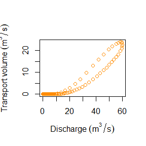

```r
plot(out_put$Q, out_put$Vb,
     col = "darkorange",
     pch = 21,
     type = "b",
     xlab = expression(Discharge~(m^3/s)),
     ylab = expression(Transport~volume~(m^3/s)))
```

The volume that would be transported if bank erosion did not occur can be estimated by putting in a very high bank strength value. However, this analysis assumes that the channel is rectangular, and does not capture the effects of changing channel width with flood stage. If bank erosion can be ignored, it is more appropriate to use apply the `estimate_capacity()` function above to a real cross section instead of using functions relying on `gbem()`.

```r
#repeat analysis with higher bank strength
river_H <- 5
out_put <- bank_erode_fp(test_hydrograph, dt, river_n, river_d84, river_d50, river_w0, river_slope, river_H)

total_transport_volume <- sum(out_put$Vb)
print(total_transport_volume)
```

```
## [1] 689.7506
```

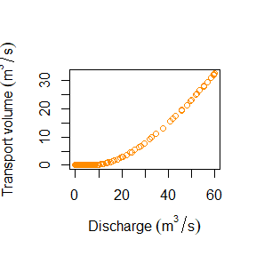

```r
plot(out_put$Q, out_put$Vb,
     col = "darkorange",
     pch = 21,
     type = "b",
     xlab = expression(Discharge~(m^3/s)),
     ylab = expression(Transport~volume~(m^3/s)))
```

### See also

`bank_erode_trc()` `gbem()`

## bank_erode_trc

Estimate the cumulative bank erosion during a flood hydrograph in an incized channel

### Usage

`bank_erode_trc( Q, t, n, D84, D50, W, S, H = 0, Z, fun = "ec", g = 9.81, rho_s = 2650, rho = 1000 )`

### Arguments

- `Q` a list of discharge values at regular time intervals defining the flood hydrograph (m$^3$/s)
- `t` time interval between discharge measurements (hrs)
- `n` Manning’s n value for the main channel
- `D84` 84th percentile of the surface grain size distribution (m)
- `D50` 50th percentile of the grain size distribution (m)
- `W` water surface width at the beginning of time interval t
- `S` energy gradient of the stream channel (m/m)
- `H` effective rooting depth for vegetation grassy banks, no trees / shrubs H = 0.35; 1 to 5percent tree / shrub cover H = 0.50; 5 to 50percent tree / shrub cover H = 0.90; more than 50percent tree / shrub cover H = 1.1
- `Z` height of the terrace above the channel bottom (m)
- `fun` choice of transport function. Default is Eaton and Church (“ec”)
- `g` the acceleration of gravity. defaults to 9.81 m/s$^2$
- `rho_s` sediment density. Defaults to 2650 kg/m$^3$
- `rho` fluid density. Defaults to 1000 kg/m$^3$

### Details

This function implements the GBEM model for estimating bank erosion using a simple adjustment parameter to adapt the standard model for streams where the channel is incised, and confined by a terrace. The function outputs a data frame containing variables for time since the start of the hydrograph (time), discharge values for each time (Q), the predicted bank erosion distance for the time step (erosion), the volume of sediment transport that the stream can convey during the timestep (vb), the critical depth for bank erosion (dc), channel width at the end of each timestep (wi)

### Output

The function outputs a data frame with values for each time step in the simulation. The variables in the data frame are:

- time (in hours)
- discharge (in m$^3$/s)
- predicted bank erosion for the time step (in m)
- volume of bedload transported across the entire channel during the time step (in m$^3$)
- the critical depth for the occurrence of bank erosion (a constant value, in m)
- the simulated channel width at the end of each time step (m)

### Examples

Here is an example of the function.

```r
#use the flood hydrograph created above for bank_erode_fp


#use the same river reach details as for bank_erode_fp
river_H <- 0.5
river_Z <- 2.5

out_put <- bank_erode_trc(test_hydrograph, dt, river_n, river_d84, river_d50, river_w0, river_slope, river_H, river_Z)
head(out_put)
```

```
##   time    Q      depth erosion           Vb        dc wi
## 1    1 0.00 0.00000000       0 0.000000e+00 0.7826946 25
## 2    2 0.75 0.07833924       0 0.000000e+00 0.7826946 25
## 3    3 1.50 0.11874008       0 0.000000e+00 0.7826946 25
## 4    4 2.85 0.17452172       0 4.481413e-07 0.7826946 25
## 5    5 4.60 0.23259334       0 1.533149e-03 0.7826946 25
## 6    6 6.45 0.28489079       0 2.401352e-02 0.7826946 25
```

The total change in width and the total volume of bedload transport can be calculated from the data. Note that this estimate reflects the decline in transport rate due to channel widening, resulting in a hysteresis loop in the data.

```r
total_width_increase <- sum(out_put$erosion)
print(total_width_increase)
```

```
## [1] 9.378277
```

```r
total_transport_volume <- sum(out_put$Vb)
print(total_transport_volume)
```

```
## [1] 561.7546
```

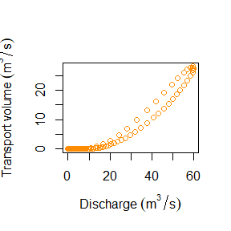

```r
plot(out_put$Q, out_put$Vb,
     col = "darkorange",
     pch = 21,
     type = "b",
     xlab = expression(Discharge~(m^3/s)),
     ylab = expression(Transport~volume~(m^3/s)))
```

Compared to the same analysis using `bank_erode_fp()` the amount of widening is lower and the total transport volume is higher, reflecting the fact that this stream is confined by a terrace.

### See also

`bank_erode_fp()`, `gbem()`

## step_length

Calculating the step length for sediment transport of coarse bed material

### Usage

`step_length( D50, q, d, S, dt, flashy = FALSE, use_ferguson = TRUE, g = 9.81, rho = 1000 )`

### Arguments

- `D50` median bed sediment grain diameter (m)
- `q` a list of specific discharge values for a hydrograph (m3/s/m)
- `d` flow depth at the bankfull stage (m)
- `S` gradient of the water surface slope (m/m)
- `dt` time interval between discharge measurements (hrs)
- `flashy` a logical variable (true if the hydrograph is short and flashy)
- `use_ferguson` logical variable for selecting the ferguson equation for calculating the critical stream power}
- `g` the acceleration of gravity. defaults to 9.81 m/s$^2$
- `rho` fluid density. Defaults to 1000 kg/m$^3$

### Details

this function calculates the average distance for bedload transport during a flow of a given duration. This is a good tool for estimating potential relations between sediment sources and sediment deposition areas. It addresses only the coarse sediment that moves along the channel bed, not the silt, sand and finer granules that can move in saltation of suspension modes.

### Output

### Examples

Here is an example of the function in use for Fishtrap Creek, where tracers were deployed in 2006.

```r
#simulate the hydrograph
Q <- scs_hydrograph(Qpeak = 7,
                    tpeak = 8,
                    dt = 1)[[2]]
q <- Q / 6  #channel is approximately 6 m wide
d <- 0.6  #estimated bankfull depth
D50 <- 0.05
Slope <- 0.02

#use same values for stream evaluated in bank_erode_pf() and bank_erode_trc()
step_length(D50, q, d, Slope, 1, flashy = FALSE, use_ferguson = TRUE)
```

```
## [1] 42.43703
```

Typically, step length during a bankfull flow is on the order of 5 to 10 times the channel width, depending on the flood duration, which in this case lines up with the estimate assuming that the flood was not particularly flashing and using the Ferguson (2005) to estimate the critical stream power for entrainment.

The estimation of step length is very sensitive to the quality of the input data, particularly the estimate of the specific discharge value. If little is known about the hydrograph shape, it is appropriate to assume the flood is flashy, in which case a function using only the peak specific discharge is used.

### See also

`crit_power()`, `unit_power()`

## quick_ffa_ann

This function uses the `RivRetrieve` package to source and download all available daily discharge measurements for any Water Survey of Canada of USGS gauging station, identify the maximum flows, and perform a flood frequency analysis using maximum likelihood estimation to fit a Generalized Extreme Value distribution to the data.

### Usage

`quick_ffa_ann(station, rp, qual)`

### Arguments

`station` a string containing the station name (e.g. ‘08GA022’ or ‘14048000’)

`rp` a vector containing the return periods for which to estimate flood quantiles. Default values are 2, 5, 10, 20, 50, 100, and 200 yrss

`qual` a value from 0 to 1 specifying how complete an annual dataset should be in order to estimate an annual maximum discharge value for that year. Default value is 0.6.

### Details

When applying this function for the first time to data from the Water Survey of Canada, you will need to first run `tidyhydat::download_hydat()` to download the hydat database on your computer. Data from the USGS is provided from an online repository and no additional installation in necessary.

### Output

The function produces a graph showing the data and the fitted GEV model, and outputs a data frame containing flood quantiles for the specified return periods.

### Examples

The following example shows the function applied to a USGS station and a WSC station.

```r
# if running for the first time, also run...
# tidyhydat::download_hydat()

wsc_test <- quick_ffa_ann('08GA022')
```

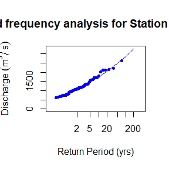

```r
print(wsc_test)
```

```
##   return_period estimate
## 1             2     1090
## 2             5     1470
## 3            10     1750
## 4            20     2050
## 5            50     2490
## 6           100     2860
## 7           200     3270
```

```r
usgs_test <-quick_ffa_ann('12150800')
```

```
## GET: https://waterservices.usgs.gov/nwis/dv/?site=12150800&format=waterml%2C1.1&ParameterCd=00060&StatCd=00003&startDT=1900-01-01&endDT=2025-12-10
```

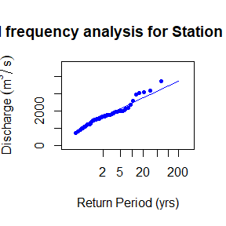

```r
print(usgs_test)
```

```
##   return_period estimate
## 1             2     1650
## 2             5     2150
## 3            10     2470
## 4            20     2780
## 5            50     3170
## 6           100     3460
## 7           200     3740
```

### See also

`quick_ffa_dual()`

## quick_ffa_dual

Estimate flood quantiles for dual mechanism daily maximum flows

### Usage

`quick_ffa_dual( station, start = "04-01", end = "07-01", rp = c(2, 5, 10, 20, 50, 100, 200), qual = 0.6 )`

### Arguments

- `station` a string containing the station name (e.g. ‘08GA022’ or ‘14048000’)
- `start` a string specifying the beginning of the melt window in MM-DD format
- `rp` a vector containing the return periods for which to estimate flood quantiles
- `qual` a value from 0 to 1 specifying how complete an annual dataset should be in order to estimate an annual maximum discharge value for that year

### Details

This function loads data from WSC or USGS stations and fits a generalized extreme value (GEV) distribution to the data using maximum likelihood estimation.

### Output

The function produces a graph showing the data and the fitted GEV model, and outputs a data frame containing flood quantiles for the specified return periods.

### Examples

```r
# if running for the first time, also run...
# tidyhydat::download_hydat()

wsc_test <- quick_ffa_dual('08MF065',
                           start = '04-01',
                           end = '07-01')
```

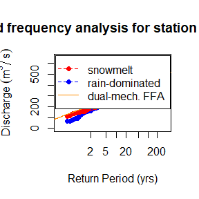

```r
print(wsc_test)
```

```
##   return_period estimate
## 1             2      208
## 2             5      256
## 3            10      290
## 4            20      325
## 5            50      375
## 6           100      416
## 7           200      459
```

```r
usgs_test <-quick_ffa_dual('12451000',
                           start = '04-01',
                           end = '07-01')
```

```
## GET: https://waterservices.usgs.gov/nwis/dv/?site=12451000&format=waterml%2C1.1&ParameterCd=00060&StatCd=00003&startDT=1900-01-01&endDT=2025-12-10
```

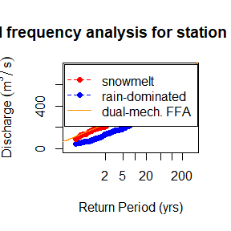

```r
print(usgs_test)
```

```
##   return_period estimate
## 1             2      232
## 2             5      300
## 3            10      345
## 4            20      391
## 5            50      455
## 6           100      519
## 7           200      619
```

### See also

`quick_ffa_ann()`

## max_min_timing

## flow_regime

# Hydraulics Functions

## u_ferg

Estimating the mean flow velocity using the Ferguson 2007 equation.

### Usage

`u_ferg(R, S, d84, a1 = 6.5, a2 = 2.5, g = 9.81)`

### Arguments

- `R` hydraulic radius for the flow (m)
- `S` gradient of the water surface slope (m/m)
- `d84` 84th percentile diameter of bed sediment (m)
- `a1` constant fit by Ferguson (2007). Defaults to 6.5
- `a2` constant fit by Ferguson (2007). Defaults to 2.5
- `g` the acceleration of gravity. defaults to 9.81 m/s$^2$

### Details

This function uses the Ferguson (2007) flow resistance law to estimate the mean velocity of the flow using the bed surface D84

### Output

### Examples

### See also

## tau_1D

Calculating the cross section average shear stress

### Usage

`tau_1D(R, S, g = 9.81, rho = 1000)`

### Arguments

- `R` hydraulic radius for the flow (m)
- `S` gradient of the water surface slope (m/m)
- `g` the acceleration of gravity. defaults to 9.81 m/s$^2$
- `rho` fluid density. Defaults to 1000 kg/m$^3$

### Details

this function calculates the average shear stress acting on the channel boundary for a given cross section.

### Output

### Examples

### See also

## t_star

Estimating the dimensionless shear stress

### Usage

`t_star(tau, d, g = 9.81, rho = 1000, rho_s = 2650)`

### Arguments

- `tau` the cross section-averaged shear stress (Pa/m$^2$)
- `d` median bed sediment grain diameter (m)
- `g` the acceleration of gravity. defaults to 9.81 m/s$^2$
- `rho` fluid density. Defaults to 1000 kg/m$^3$
- `rho_s` sediment density. Defaults to 2650 kg/m$^3$

### Details

This function calculates the dimensionless shear stress using the bed surface median grain size.

### Output

### Examples

### See also

## unit_power

Calculating the cross section average unit stream power

### Usage

`unit_power(q, S, g = 9.81, rho = 1000)`

### Arguments

- `q` specific discharge (m$^3$/s/m)
- `S` gradient of the water surface slope (m/m)
- `g` the acceleration of gravity. defaults to 9.81 m/s$^2$
- `rho` fluid density. Defaults to 1000 kg/m$^3$

### Details

this function calculates the unit stream power acting on the channel boundary for a given cross section.

### Output

### Examples

### See also

# Sediment Transport Functions

## mpm

Estimating bedload transport using Meyer Peter and Muller

### Usage

`mpm(R, S, d, t_crit = 0.047, g = 9.81, rho = 1000, rho_s = 2650)`

### Arguments

- `R` hydraulic radius for the flow (m)
- `S` gradient of the water surface slope (m/m)
- `d` median bed sediment grain diameter (m)
- `t_crit` critical dimensionless shear stress. Defaults to 0.047
- `g` the acceleration of gravity. defaults to 9.81 m/s$^2$
- `rho` fluid density. Defaults to 1000 kg/m$^3$
- `rho_s` sediment density. Defaults to 2650 kg/m$^3$

### Details

This function uses a dimensionless form of the traditional Meyer Peter and Muller equation to estimate the dimensionless bedload flux for a given shear stress and characteristic grain size.

### Output

### Examples

### See also

## wp

Estimating bedload transport using Wong and Parker (2006)

### Usage

`wp(R, S, d, t_crit = 0.047, g = 9.81, rho = 1000, rho_s = 2650)`

### Arguments

- `R` hydraulic radius for the flow (m)
- `S` gradient of the water surface slope (m/m)
- `d` median bed sediment grain diameter (m)
- `t_crit` critical dimensionless shear stress. Defaults to 0.047
- `g` the acceleration of gravity. defaults to 9.81 m/s$^2$
- `rho` fluid density. Defaults to 1000 kg/m$^3$
- `rho_s` sediment density. Defaults to 2650 kg/m$^3$

### Details

This function uses a dimensionless form of a modified version of Meyer Peter and Muller equation to estimate the dimensionless bedload flux for a given shear stress and characteristic grain size. Using the original Meyer Peter and Muller equation will produce higher transport estimates and is more conservative than using this modified version.

### Output

### Examples

### See also

## eb

Estimating bedload transport using Einstein and brown (1950)

### Usage

`eb(R, S, d, g = 9.81, rho = 1000, rho_s = 2650, kv = 1e-06)`

### Arguments

- `R` hydraulic radius for the flow (m)
- `S` gradient of the water surface slope (m/m)
- `d` median bed sediment grain diameter (m)
- `g` the acceleration of gravity. defaults to 9.81 m/s$^2$
- `rho` fluid density. Defaults to 1000 kg/m$^3$
- `rho_s` sediment density. Defaults to 2650 kg/m$^3$
- `kv` kinematic viscosity of water. Defaults to 1e$^-6$

### Details

This function uses a dimensionless form of Einstein and brown (1950) bedload transport function for use with sand bed rivers and gravel bed rivers.

### Output

### Examples

### See also

## yln

Estimating bedload transport using Yalin (1963)

### Usage

`yln( R, S, d, t_crit = t_crit_soul(d), g = 9.81, rho = 1000, rho_s = 2650, kv = 1e-06 )`

### Arguments

- `R` hydraulic radius for the flow (m)
- `S` gradient of the water surface slope (m/m)
- `d` median bed sediment grain diameter (m)
- `t_crit` critical dimensionless shear stress, calculated using Soulsby (1997)
- `g` the acceleration of gravity. defaults to 9.81 m/s$^2$
- `rho` fluid density. Defaults to 1000 kg/m$^3$
- `rho_s` sediment density. Defaults to 2650 kg/m$^3$
- `kv` kinematic viscosity of water. Defaults to 1e$^-6$

### Details

This function uses a dimensionless form of Yalin’s (1963) bedload transport function for use with sand bed rivers and gravel bed rivers.

### Output

### Examples

### See also

## vr

Estimating bedload transport using Van Rijn (1984)

### Usage

- `R` hydraulic radius for the flow (m)
- `S` gradient of the water surface slope (m/m)
- `d` median bed sediment grain diameter (m)
- `t_crit` critical dimensionless shear stress
- `g` the acceleration of gravity. defaults to 9.81 m/s$^2$
- `rho` fluid density. Defaults to 1000 kg/m$^3$
- `rho_s` sediment density. Defaults to 2650 kg/m$^3$
- `kv` kinematic viscosity of water. Defaults to 1e$^-6$

### Details

This function uses a dimensionless form of Van Rijn’s (1984) bedload transport function for use with sand bed rivers.

### Output

### Examples

### See also

## wc

Estimating fractional bedload transport using Wilcock and Crowe (2003) in m3/second

### Usage

`wc(R, S, gsd, Fsand, g = 9.81, rho = 1000, rho_s = 2650)`

### Arguments

- `R` hydraulic radius for the flow (m)
- `S` gradient of the water surface slope (m/m)
- `gsd` a data frame describing the grain size distribution created with function wolman_gsd()
- `Fsand` proportion of the surface that is covered by sand sized sediment (affects entrainment, typically varies from 0 to 0.2)
- `g` the acceleration of gravity. defaults to 9.81 m/s$^2$
- `rho` fluid density. Defaults to 1000 kg/m$^3$
- `rho_s` sediment density. Defaults to 2650 kg/m$^3$
- `counts` number of stones in each size class size class bounds (!!!must start with a 0!!!)

### Details

This function uses the Wilcock and Crowe transport function on standard data from a surface Wolman count to estimate the fraction-specific transport rate for a given shear stress. Output is a data frame containing inputted GSD information for each size class (Di, cpf, Dm, Fi), as well as the dimensionless transport rate (Wi), the volumetric transport rate per unit width (qbi), and the fraction of the computed bedload in each size class (Li)

### Output

### Examples

### See also

## ec

Estimating bed material transport using Eaton and Church (2011)

### Usage

`ec( R, S, d, d84 = 2 * d, g = 9.81, rho = 1000, rho_s = 2650, U = u_ferg(R, S, d84, a1, a2, g), a1 = 6.5, a2 = 2.5, kv = 1e-06, t_crit = t_crit_soul(d, rho, rho_s, g, kv) )`

### Arguments

- `R` hydraulic radius for the flow (m)
- `S` gradient of the water surface slope (m/m)
- `d` median bed sediment grain diameter (m)
- `d84` 84th percentile diameter of bed sediment (m). Defaults to 2 * d
- `g` the acceleration of gravity. defaults to 9.81 m/s$^2$
- `rho` fluid density. Defaults to 1000 kg/m$^3$
- `rho_s` sediment density. Defaults to 2650 kg/m$^3$
- `U` mean flow velocity. Defaults to flows calculated using Ferguson
- `a1` constant fit by Ferguson (2007). Defaults to 6.5
- `a2` constant fit by Ferguson (2007). Defaults to 2.5
- `kv` kinematic viscosity of water. Defaults to 1e$^-6$
- `t_crit` critical dimensionless shear stress, calculated using Soulsby (1997)

### Details

This function uses a dimensionless stream power equation from Eaton and Church (2011) to estimate bed material load transport in sand bed rivers and gravel bed rivers.

### Output

### Examples

### See also

## rk

Estimating bed material transport using Recking (2013)

### Usage

`rk(R, S, d, d84 = 2 * d, g = 9.81, rho = 1000, rho_s = 2650, rp = FALSE)`

### Arguments

- `R` hydraulic radius for the flow (m)
- `S` gradient of the water surface slope (m/m)
- `d` median bed sediment grain diameter (m)
- `d84` 84th percentile diameter of bed sediment (m). Defaults to 2 * d
- `g` the acceleration of gravity. defaults to 9.81 m/s$^2$
- `rho` fluid density. Defaults to 1000 kg/m$^3$
- `rho_s` sediment density. Defaults to 2650 kg/m$^3$
- `rp` option to select equation suited to riffle pool morphology, default is FALSE

### Details

This function uses a dimensionless shear stress equation from Recking based on the D84 of the bed surface, and is the version for use with field data.

### Output

### Examples

### See also

# Bed Entrainment Functions

## qb_conversion

Converting dimensionless bedload flux to volumetric flux

### Usage

`qb_conversion(q_star, d, g = 9.81, Gs = 1.65)`

### Arguments

- `q_star` dimensionless bedload flux}
- `d` median bed sediment grain diameter (m)
- `g` the acceleration of gravity. defaults to 9.81 m/s$^2$
- `Gs` the submerged specific gravity of sediment. Defaults to 1.65

### Details

this function converts dimensionless bedload transport flux values to fluxes in cubic meters per second per meter

### Output

### Examples

### See also

## t_crit_soul

Estimating critical dimensionless shear stress

### Usage

`t_crit_soul(d, rho = 1000, rho_s = 2650, g = 9.81, kv = 1e-06)`

### Arguments

- `d` median bed sediment grain diameter (m)
- `rho` fluid density. Defaults to 1000 kg/m$^3$
- `rho_s` sediment density. Defaults to 2650 kg/m$^3$
- `g` the acceleration of gravity. defaults to 9.81 m/s$^2$
- `kv` kinematic viscosity of water. Defaults to 1e$^-6$

### Details

Using the equation published by Soulsby (1997), this function estimates the critical dimensionless shear stress as a function of grain size.

### Output

### Examples

### See also

## t_crit_vr

Estimating critical dimensionless shear stress

### Usage

`t_crit_vr(d, rho = 1000, rho_s = 2650, g = 9.81, kv = 1e-06)`

### Arguments

- `d` median bed sediment grain diameter (m)
- `rho` fluid density. Defaults to 1000 kg/m$^3$
- `rho_s` sediment density. Defaults to 2650 kg/m$^3$
- `g` the acceleration of gravity. defaults to 9.81 m/s$^2$
- `kv` kinematic viscosity of water. Defaults to 1e$^-6$

### Details

Using the equation published by Van Rijn (1984), this function estimates the critical dimensionless shear stress as a function of grain size.

### Output

### Examples

### See also

## t_ref_star

Estimating reference dimensionless shear stress for Wilcock & Crowe (2003)

### Usage

`t_ref_star(Fsand)`

### Arguments

- `Fsand` Proportion of sand on the bed surface

### Details

Using the equation published by Wilcock & Crow, this function estimates the reference dimensionless shear stress based on the fraction of sand on the bed.

### Output

### Examples

### See also

## crit_power

Estimating critical stream power for bed entrainment

### Usage

`crit_power(D50, d, use_ferguson = TRUE)`

### Arguments

- `D50` median bed sediment grain diameter (mm)
- `d` flow depth (m)

### Details

Using the equation published by Ferguson (2005) or Petit et al. (2005), this function estimates the critical stream power as a function of grain size, and flow depth. These empirical equations are valid for D50 ranging from 20 to 150 mm

### Output

### Examples

### See also

# Data Import / Analysis / Simulation Functions

## scs_hydrography

Creating a hydrograph based on the Standard SCS Dimensionless Unit Hydrograph

### Usage

`scs_hydrograph(Qpeak, tpeak, dt)`

### Arguments

- `Qpeak` the peak instantaneous discharge to be reached during the hydrograph (cumecs)
- `tpeak` the lag time between the peak rainfall input and the peak runoff (hours)
- `dt` a parameter that controls the time increment for data output (in hours)

### Details

This function uses the Soil Conservation Service Standard Unit Hydrograph to simulate a simple hydrograph associated with a rainfall event. The hydrograph depends on a parameter controlling the peak flow that will be reached and a parameter controlling how quickly the hydrograph will rise and fall. The shape of the hydrograph remains the same.

The dimensionless unit hydrograph used by the SCS was developed by Victor Mockus and was derived based on a large number of unit hydrographs from basins that varied in characteristics such as size and geographic location. The unit hydrographs were averaged and the final product was made dimensionless by considering the ratios of Q/Qpeak (flow/peak flow) on the ordinate axis and t/tpeak (time/time to peak) on the abscissa. This final, dimensionless unit hydrograph, which is the result of averaging a large number of individual dimensionless unit hydrographs, has a time-to-peak located at approximately 20 percent of its time base and an inflection point at 1.7 times the time-to-peak.

### Output

### Examples

### See also

## wolman_gsd

Processing Wolman count data into grain size distribution

### Usage

`wolman_gsd(Di, counts)`

### Arguments

- `Di` a list of grain sizes representing the upper bounds of the size classes
- `counts` the number of stones sampled in the szie class defined by the upper bound values, Di

This function uses standard data from a surface Wolman count to estimate cumulative percent finer for each size, the fraction of the distribution in a given size class, and the median size of each size class. Output is a data frame containing the upper limit of each size class (Di), the cumulative proportion finer than the size listed in Di (cpf), the median size for each size class (Dm), and the fraction of the distribution in each class (Fi)

### Output

### Examples

### See also

## make_trapezoid

Create a cross section based on measured trapezoid dimensions

### Usage

`make_trapezoid(w_top, w_bot, H_bank, Z_fp, dx = 0.1)`

### Arguments

- `w_top` measured or estimated top width of the trapezoid (m)
- `w_bot` measured or estimated bottom width of the trapezoid (m)
- `H_bank` measures or estimated vertical height of the trapezoid (m)
- `dx` a parameter controlling the spacing between exported data points on the section
- `z_fp` elevation of the top of the trapezoid (i.e. the floodplain or terrace elevation, m)

### Details

This function creates profile data including the distance along the profile from the left bank.

### Output

### Examples

### See also

## load_section

Load cross section data

### Usage

`load_section(xs_nm, dx = NA, rev = FALSE, trim = FALSE, mkplt = FALSE)`

### Arguments

- `xs_nm` path to a csv file with 3 columns containing the profile data
- `dx` optional dist. increment to resample section at regular intervals (m)
- `rev` option to reverse the direction in which distance is measured
- `trim` option to identify left & right banks and trim section
- `mkplt` option to make a plot of the data (original & resampled/trimed)

### Details

This function loads profile data that is saved in a text file (XYZ format) and calculates the distance along the profile from the first data point in the file. The function assumes that the first row is header information, and that the data in column 1 correspond to x coordinates (or eastings), column 2 corresponds to y coordinates (northings), and column 3 corresponds to elevation.

### Output

### Examples

### See also

# Utility Functions

## find_q_b

Calculating volumetric unit transport rate for a specified function

### Usage

`find_q_b(R, S, D50, D84, fun = "ec", g = 9.81, rho = 1000, rho_s = 2650)`

### Arguments

- `R` hydraulic radius for the flow (m)
- `S` gradient of the water surface slope (m/m)
- `D50` 50th percentile of the grain size distribution (m)
- `D84` 84th percentile of the surface grain size distribution (m)
- `fun` choice of transport function. Default is Eaton and Church (“ec”)
- `g` the acceleration of gravity. defaults to 9.81 m/s$^2$
- `rho` fluid density. Defaults to 1000 kg/m$^3$
- `rho_s` sediment density. Defaults to 2650 kg/m$^3$

### Details

This function takes the hydraulic data required to calculate the dimensionless shear stress and uses a specified bedload transport function to calculate the volumetric transport rate per unit width.

## find_d_crit

find the critical depth at which bank erosion will begin

### Usage

`find_d_crit(Q, H, t_c84, S, g = 9.81, rho = 1000, tol = 0.001)`

### Arguments

- `Q` a list of discharge values at regular time intervals defining the flood hydrograph (m$^3$/s)
- `H` effective rooting depth for vegetation
- `t_c84` stress required to entrain the 84th percentile of the bed surface
- `S` energy gradient of the stream channel (m/m)
- `g` the acceleration of gravity. defaults to 9.81 m/s$^2$
- `rho` fluid density. Defaults to 1000 kg/m$^3$

### Details

this is a utility function used by GBEM to determine the typical floodplain thickness above the channel bed. ***

## est_mu

estimate relative bank strength

### Usage

`est_mu(H, d)`

### Arguments

- `H` effective rooting depth for vegetation}
- `d` channel depths}

### Details

this is a utility function used by GBEM to determine the relative bank strength given the channel depth and rooting depth. It returns a variable that is the bank strength relative to the bed strengths.

## d_star

Estimating dimensionless particle size

### Usage

`d_star(d, Gs = 1.65, g = 9.81, kv = 1e-06)`

### Arguments

- `d` median bed sediment grain diameter (m)
- `Gs` the submerged specific gravity of sediment. Defaults to 1.65
- `g` the acceleration of gravity. defaults to 9.81 m/s$^2$
- `kv` kinematic viscosity of water. Defaults to 1e$^-6$

### Details

this function estimates the dimensionless particle size

## calc_depths

### Usage

`calc_depths(xs_data, wse, mkplt = F)`

### Arguments

- `xs_data` a data frame containing $dist (distances) and $z (elevations)
- `wse` elevation of the water surface of interest (m)
- `mkplt` logical option to plot the data, default is FALSE}

### Details

this function uses a water surface elevation (WSE) and the location index for the channel thalweg to calculate the depths in the main channel. disconnected areas outside the main channel that are below the WSE are located and assigned a depth of NA. This is particularly important on a fan